# IODS course final project

Volkova Anastasia, mibisako@gmail.com

18.12.2017

## **IODS Final Project**

**Abstract: Using the results of a survey on teaching and learning conducted by Kimmo Vehkalahti in 2014, a relationship between deep and strategic learning approaches had been found out using the binary regression. Gender, age, or attitudes towards subject of the course had no significant effect on the choice between deep or surface approaches**

*I want to explore deep and surface learning approaches using binary logistic regression. I suppose that older students prefer deep LA in contrast to younger. I do not expect any gender differences. I also suppose that general attitude towards statistics may highly influence the LA - if people are not interested, they are more likely to use surface approach.*

# Data

```r
library(ggplot2)
library(GGally)
library(dplyr)
library(tidyr)
task<-read.table("C:/Users/Missao/Documents/GitHub/IODS-final/learning2014.txt", header=TRUE, sep="\t")
str(task)
```

```
## 'data.frame':    166 obs. of  11 variables:
##  $ gender            : Factor w/ 2 levels "F","M": 1 2 1 2 2 1 2 1 2 1 ...
##  $ Age               : int  53 55 49 53 49 38 50 37 37 42 ...
##  $ attitude          : num  3.7 3.1 2.5 3.5 3.7 3.8 3.5 2.9 3.8 2.1 ...
##  $ deep              : num  3.58 2.92 3.5 3.5 3.67 ...
##  $ stra              : num  3.38 2.75 3.62 3.12 3.62 ...
##  $ surf              : num  2.58 3.17 2.25 2.25 2.83 ...
##  $ Points            : int  25 12 24 10 22 21 21 31 24 26 ...
##  $ deep_adjusted     : num  0.299 0.243 0.292 0.292 0.306 ...
##  $ surface_adjusted  : num  0.215 0.264 0.188 0.188 0.236 ...
##  $ strategic_adjusted: num  0.422 0.344 0.453 0.391 0.453 ...
##  $ DS                : int  1 0 1 1 1 1 1 1 1 1 ...
```

```r
dim(task)
```

```
## [1] 166  11
```

```r
names(task)
```

```
##  [1] "gender"             "Age"                "attitude"
##  [4] "deep"               "stra"               "surf"
##  [7] "Points"             "deep_adjusted"      "surface_adjusted"
## [10] "strategic_adjusted" "DS"
```

The dataset is the results of a survey on teaching and learning conducted by Kimmo Vehkalahti in 2014. Additional information about this research project can be found here https://www.slideshare.net/kimmovehkalahti/the-relationship-between-learning-approaches-and-students-achievements-in-an-introductory-statistics-course-in-finland and there http://www.helsinki.fi/~kvehkala/JYTmooc/JYTOPKYS2-meta.txt.

It has 166 observations of 11 variables. Learning approaches variables were created out of related questions and then adjusted.

We are most interested in two approaches, that lies in the DS variable, where

**1** = Deep: Seeking Meaning, Relating Ideas, Use of Evidence, and

**0** = Surface: Lack of Purpose, Unrelated Memorising, Syllabus-boundness.

# Correlations and visualizations

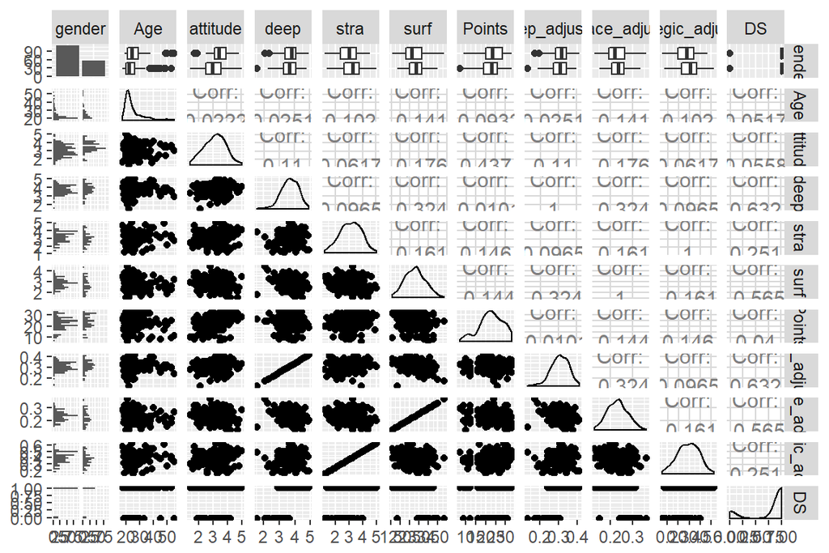

```r
library(ggplot2)
library(GGally)
ggpairs(task, lower = list(combo = wrap("facethist", bins = 20)))
```

To see what can influence the probabilities of choosing deep or surface approach a *binary logistic regression* will be used.

# Binary logistic regression

```r
m1 <- glm(DS ~ strategic_adjusted + gender + Age + attitude, data = task, family = "binomial")
summary(m1)
```

```
##
## Call:
## glm(formula = DS ~ strategic_adjusted + gender + Age + attitude,
##     family = "binomial", data = task)
##
## Deviance Residuals:
##     Min       1Q   Median       3Q      Max
## -2.3115   0.3555   0.5089   0.6978   1.1088
##
## Coefficients:
##                    Estimate Std. Error z value Pr(>|z|)
## (Intercept)        -2.14775    1.47048  -1.461  0.14413
## strategic_adjusted  6.86574    2.30761   2.975  0.00293 **
## genderM            -0.20669    0.46016  -0.449  0.65331
## Age                 0.01528    0.03064   0.499  0.61811
## attitude            0.24702    0.30604   0.807  0.41958
## ---
## Signif. codes:  0 '***' 0.001 '**' 0.01 '*' 0.05 '.' 0.1 ' ' 1
##
## (Dispersion parameter for binomial family taken to be 1)
##
##     Null deviance: 159.85  on 165  degrees of freedom
## Residual deviance: 148.29  on 161  degrees of freedom
## AIC: 158.29
##
## Number of Fisher Scoring iterations: 5
```

```r
library(rcompanion)
nagelkerke(m1)
```

```
## $Models
##
## Model: "glm, DS ~ strategic_adjusted + gender + Age + attitude, binomial, task"
## Null:  "glm, DS ~ 1, binomial, task"
##
## $Pseudo.R.squared.for.model.vs.null
##                              Pseudo.R.squared
## McFadden                            0.0722876
## Cox and Snell (ML)                  0.0672414
## Nagelkerke (Cragg and Uhler)        0.1087640
##
## $Likelihood.ratio.test
##  Df.diff LogLik.diff  Chisq  p.value
##       -4     -5.7775 11.555 0.020986
##
## $Number.of.observations
##
## Model: 166
## Null:  166
##
## $Messages
## [1] "Note: For models fit with REML, these statistics are based on refitting with ML"
##
## $Warnings
## [1] "None"
```

```r
OR <- coef(m1) %>% exp # compute odds ratios (OR)
CI <- confint(m1) %>% exp # compute confidence intervals (CI)
cbind(OR, CI)
```

```
##                             OR        2.5 %       97.5 %
## (Intercept)          0.1167464  0.005584649 1.884363e+00
## strategic_adjusted 958.8522864 11.880312815 1.073686e+05
## genderM              0.8132744  0.331932092 2.043208e+00
## Age                  1.0153947  0.960979218 1.086581e+00
## attitude             1.2802027  0.703080053 2.353576e+00
```

# Final model and predictions

```r
m10 <- glm(DS ~ strategic_adjusted, data = task, family = "binomial")
summary(m10)
```

```
##
## Call:
## glm(formula = DS ~ strategic_adjusted, family = "binomial", data = task)
##
## Deviance Residuals:
##     Min       1Q   Median       3Q      Max
## -2.2215   0.3994   0.5182   0.7000   1.1460
##
## Coefficients:
##                    Estimate Std. Error z value Pr(>|z|)
## (Intercept)         -1.1329     0.8204  -1.381  0.16730
## strategic_adjusted   7.0237     2.2480   3.124  0.00178 **
## ---
## Signif. codes:  0 '***' 0.001 '**' 0.01 '*' 0.05 '.' 0.1 ' ' 1
##
## (Dispersion parameter for binomial family taken to be 1)
##
##     Null deviance: 159.85  on 165  degrees of freedom
## Residual deviance: 149.17  on 164  degrees of freedom
## AIC: 153.17
##
## Number of Fisher Scoring iterations: 4
```

```r
nagelkerke(m10)
```

```
## $Models
##
## Model: "glm, DS ~ strategic_adjusted, binomial, task"
## Null:  "glm, DS ~ 1, binomial, task"
##
## $Pseudo.R.squared.for.model.vs.null
##                              Pseudo.R.squared
## McFadden                            0.0668221
## Cox and Snell (ML)                  0.0623194
## Nagelkerke (Cragg and Uhler)        0.1008030
##
## $Likelihood.ratio.test
##  Df.diff LogLik.diff  Chisq   p.value
##       -1     -5.3407 10.681 0.0010822
##
## $Number.of.observations
##
## Model: 166
## Null:  166
##
## $Messages
## [1] "Note: For models fit with REML, these statistics are based on refitting with ML"
##
## $Warnings
## [1] "None"
```

```r
OR <- coef(m10) %>% exp # compute odds ratios (OR)
CI <- confint(m10) %>% exp # compute confidence intervals (CI)
cbind(OR, CI)
```

```
##                              OR       2.5 %       97.5 %
## (Intercept)           0.3221097  0.06253891 1.597882e+00
## strategic_adjusted 1122.9035074 15.69234450 1.118797e+05
```

```r
probabilities <- predict(m10, type = "response") # predict() the probability of deep LA
task <- mutate(task, probability = probabilities) # add the predicted probabilities
task <- mutate(task, prediction = probability>0.5) # use the probabilities to make a prediction of high_use
select(task, DS, strategic_adjusted, probability, prediction) %>% tail(10) # see the last ten original classes, predicted probabilities, and class predictions
```

```
##     DS strategic_adjusted probability prediction
## 157  1           0.343750   0.7827091       TRUE
## 158  1           0.500000   0.9152098       TRUE
## 159  1           0.296875   0.7215754       TRUE
## 160  1           0.484375   0.9062963       TRUE
## 161  1           0.421875   0.8617914       TRUE
## 162  0           0.218750   0.5995439       TRUE
## 163  1           0.375000   0.8177257       TRUE
## 164  0           0.328125   0.7634665       TRUE
## 165  1           0.328125   0.7634665       TRUE
## 166  1           0.421875   0.8617914       TRUE
```

```r
table(SD = task$DS, prediction = task$prediction) # tabulate the target variable versus the predictions
```

```
##    prediction
## SD  FALSE TRUE
##   0     1   30
##   1     0  135
```

```r
table(SD = task$DS, prediction = task$prediction) %>% prop.table() %>% addmargins() # tabulate the target variable versus the predictions with margings:
```

```
##      prediction
## SD          FALSE        TRUE         Sum
##   0   0.006024096 0.180722892 0.186746988
##   1   0.000000000 0.813253012 0.813253012
##   Sum 0.006024096 0.993975904 1.000000000
```

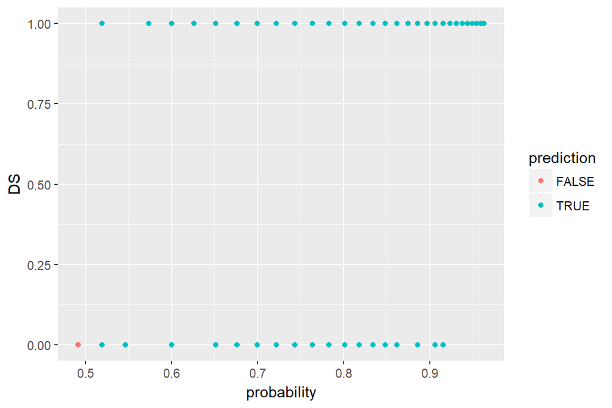

```r
g <- ggplot(task, aes(x = probability, y = DS, col = prediction)) # initialize a plot of 'high_use' versus 'probability'
g + geom_point() # define the geom as points and draw the plot
```

```r
# define a loss function (mean prediction error)
loss_func <- function(class, prob) {
  n_wrong <- abs(class - prob) > 0.5
  mean(n_wrong)
}

# call loss_func to compute the average number of wrong predictions in the (training) data
loss_func(class = task$DS, task$probability)
```

```
## [1] 0.1807229
```

The obtained model is not ideal: while there were 136 correct predictions, there also were 30 cases that were diagnosted false (Type I&II errors). But still, this is a reasonable fit, as the training error is approximately 18%.

# Conclusion

The only significant predictor for choosing the deep learning approach is the high scores on strategic learning approach. It signifies “Organized Studying and Time Management”, and this suits more for those students who are seeking meaning in contrast to those who have lack of purpose.

There is no gender or age differences in relation to the deep and surface LA. The general attitude to statistics also have no statistical importance.